# PAC_3

2025-05-13

## 1 Regressió lineal

### 1.1 Estudi de correlació lineal

Calculeu la correlació lineal entre totes les variables quantitatives de l’estudi. Mostreu la matriu de correlació i ordenar els valors de manera decreixent, és a dir del valor més alt de r, *coeficient de correlació lineal*, al més baix. Interpreteu

Primer llegim el document i mostrem les primeres files

```r
data <- read.csv("~/Documentos/GitHub/UOC-treballs/analisis_estadistic/pac3/Barcelona_Rent_Price_vf.csv", encoding="UTF-8")

kable(head(data))
```

| price | rooms | bathroom | lift | terrace | square_meters | real_state | neighborhood |
| --- | --- | --- | --- | --- | --- | --- | --- |
| 3000 | 3 | 2 | FALSE | FALSE | 150 | apartment | Eixample |
| 1250 | 1 | 1 | FALSE | FALSE | 35 | apartment | Eixample |
| 2200 | 4 | 2 | FALSE | FALSE | 90 | apartment | Gracia |
| 3468 | 3 | 2 | FALSE | FALSE | 98 | apartment | Ciutat Vella |
| 1100 | 1 | 1 | TRUE | FALSE | 45 | apartment | Les Corts |
| 2500 | 3 | 2 | TRUE | FALSE | 180 | apartment | Eixample |

Ara generarem la taula de correlacions ordenant de manera decreixent

```r
res <- cor(data[,c("price", "rooms", "bathroom","square_meters")])
order_price <- order(res[, "price"], decreasing = TRUE)
res_ordered <- res[order_price, order_price]
kable(round(res_ordered, 2))
```

|  | price | square_meters | bathroom | rooms |
| --- | --- | --- | --- | --- |
| price | 1.00 | 0.69 | 0.58 | 0.34 |
| square_meters | 0.69 | 1.00 | 0.76 | 0.65 |
| bathroom | 0.58 | 0.76 | 1.00 | 0.57 |
| rooms | 0.34 | 0.65 | 0.57 | 1.00 |

```r
n <- length( data$price )
x_price_med <- sum(data$price)/n
sx <- sum((data$price-x_price_med)**2)
correl <- data.frame(var=c("Price"), value=c(1), stringsAsFactors=FALSE)
for (i in c("rooms", "bathroom","square_meters")){
  y_med <- sum(data[[i]])/n
  sxy <- sum((data$price-x_price_med)*(data[[i]]-y_med))

  sy <- sum((data[[i]]-y_med)**2)
  r <- sxy/sqrt((sx)*(sy))
  correl <- rbind(correl, list(i,round(r,2)))
}
correl <- as.matrix(correl)
ordered <- order(correl[, "value"], decreasing = TRUE)
correl_orde <- correl[ordered,]
kable(correl_orde)
```

| var | value |
| --- | --- |
| Price | 1.00 |
| square_meters | 0.69 |
| bathroom | 0.58 |
| rooms | 0.34 |

### 1.2 Estudi comparatiu entre barris de Barcelona

Per a cada tipus d’habitatge, representeu gràficament la variació de preus segons el barri. Interpreteu. Posteriorment representeu en una taula la mitja i la mitjana dels preus del lloguer, segons tipus d’habitatge i barri.

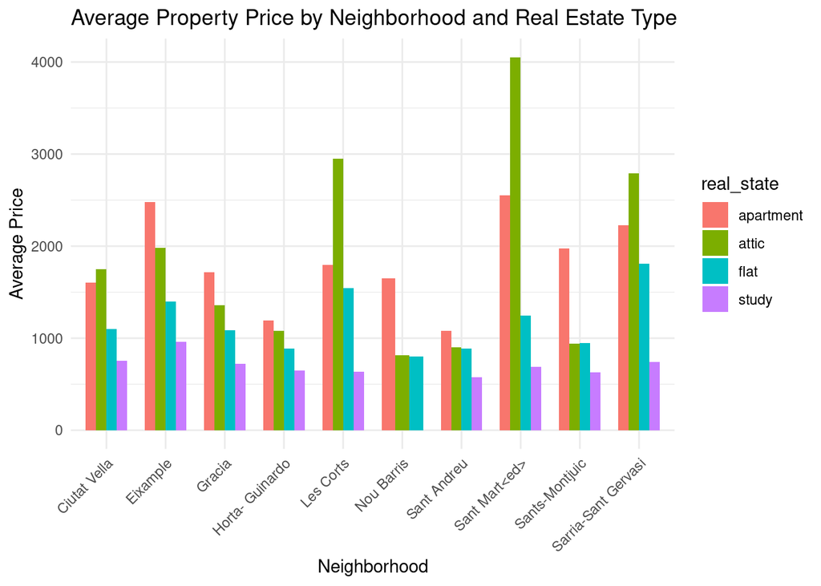

```r
library(ggplot2)
data$neighborhood <- iconv(data$neighborhood, from = "", to = "UTF-8", sub = "byte")
#data$real_state <- enc2utf8(as.character(data$real_state))
ggplot(data, aes(x=factor(neighborhood), y = price, fill=real_state)) +
  geom_bar(stat="summary", fun='mean',width=0.7, position=position_dodge()) +
  labs(title = "Average Property Price by Neighborhood and Real Estate Type",
       x = "Neighborhood",
       y = "Average Price") +
  theme_minimal() +
  theme(axis.text.x = element_text(angle = 45, hjust = 1))
```

```r
library(dplyr)
data_sumary <- data%>%
  group_by(neighborhood,real_state)%>%
   summarise(
    price_mean = mean(price, na.rm = TRUE),
    price_median = median(price, na.rm = TRUE),
    .groups = "drop"
  )
kable(data_sumary)
```

| neighborhood | real_state | price_mean | price_median |
| --- | --- | --- | --- |
| Ciutat Vella | apartment | 1601.0361 | 1360.0 |
| Ciutat Vella | attic | 1749.4118 | 1290.0 |
| Ciutat Vella | flat | 1102.6899 | 950.0 |
| Ciutat Vella | study | 756.2353 | 700.0 |
| Eixample | apartment | 2478.4947 | 2062.0 |
| Eixample | attic | 1980.5062 | 1400.0 |
| Eixample | flat | 1395.3812 | 1173.5 |
| Eixample | study | 957.7647 | 847.0 |
| Gracia | apartment | 1717.5098 | 1500.0 |
| Gracia | attic | 1359.6970 | 1100.0 |
| Gracia | flat | 1084.1533 | 960.0 |
| Gracia | study | 723.2500 | 647.5 |
| Horta- Guinardo | apartment | 1192.5714 | 973.0 |
| Horta- Guinardo | attic | 1077.4000 | 950.0 |
| Horta- Guinardo | flat | 889.7765 | 825.0 |
| Horta- Guinardo | study | 646.0000 | 600.0 |
| Les Corts | apartment | 1797.5000 | 1475.0 |
| Les Corts | attic | 2949.9000 | 2500.0 |
| Les Corts | flat | 1544.5360 | 1200.0 |
| Les Corts | study | 634.0000 | 620.0 |
| Nou Barris | apartment | 1650.0000 | 1650.0 |
| Nou Barris | attic | 815.5000 | 782.0 |
| Nou Barris | flat | 800.0943 | 780.0 |
| Sant Andreu | apartment | 1082.5000 | 1025.0 |
| Sant Andreu | attic | 903.0000 | 900.0 |
| Sant Andreu | flat | 890.0503 | 850.0 |
| Sant Andreu | study | 573.0000 | 573.0 |
| Sant Mart | apartment | 2552.4528 | 2057.0 |
| Sant Mart | attic | 4051.5789 | 1800.0 |
| Sant Mart | flat | 1242.3716 | 980.0 |
| Sant Mart | study | 690.2222 | 650.0 |
| Sants-Montjuic | apartment | 1975.5714 | 1700.0 |
| Sants-Montjuic | attic | 940.7500 | 940.0 |
| Sants-Montjuic | flat | 950.4829 | 900.0 |
| Sants-Montjuic | study | 632.0000 | 570.0 |
| Sarria-Sant Gervasi | apartment | 2230.0690 | 1775.0 |
| Sarria-Sant Gervasi | attic | 2788.6622 | 2300.0 |
| Sarria-Sant Gervasi | flat | 1809.5566 | 1306.0 |
| Sarria-Sant Gervasi | study | 744.0000 | 700.0 |

Veiem que el preus dels estudis són estables respecte els barris, això pot ser pel l’ús que se li pot donar en canvi els atics tenen molta variabilitat inclòs passant de ser una opció econòmica dintre del barri a ser la més cara. Això pot ser perquè en certs barris siguin molt més comuns o per que les vistes en la terrassa encareixin el pis. També veiem que tenim zones que es comporten similarment com Sant Andreu i Horta on la mitjana es similar. També veiem que la mitja i la mitjana són similars en general excepte en casos contats com els atics a Sant Mart això indica que hi ha uns atics molt cars que fan que la mitjana pugi molt però la mitja es quedi molt més baixa. També veiem que en general encara que similars la mitjana es més alta que la mitja. Això podria indicar que tots els barris tenen pisos molt cars i que no estan distribuïts en una normal amb centre la mitjana.

### 1.3 Generació dels conjunts d’entrenament i de test

Ara separarem el conjunt de dades en dues parts: el conjunt d’entrenament (training) i el conjunt de prova (testing). En els següents apartats, ajustarem el model de regressió lineal amb el conjunt d’entrenament, i avaluarem la precisió amb el conjunt de prova.

Es demana generar els conjunts de dades per a entrenar el model (training) i per a testar-lo (testing). Es pot fixar la grandària de la mostra d’entrenament a un 80% de l’original.

```r
smp_size <- floor(0.80 * nrow(data))

## set the seed to make your partition reproducible
set.seed(123)
train_ind <- sample(seq_len(nrow(data)), size = smp_size)

train <- data[train_ind, ]
test <- data[-train_ind, ]
```

### 1.4 Estimació del model de regressió lineal amb predictors quantitatius

Estimeu per mínims quadrats ordinaris un model lineal que expliqui el preu del lloguer en funció de totes les variables emprades per a calcular la matriu de correlacions en l’apartat anterior.

```r
model <- lm(price ~ rooms + bathroom + square_meters, data = train )
summary(model)
```

```
##
## Call:
## lm(formula = price ~ rooms + bathroom + square_meters, data = train)
##
## Residuals:
##     Min      1Q  Median      3Q     Max
## -3514.9  -305.1  -114.8   105.2 13282.8
##
## Coefficients:
##                Estimate Std. Error t value Pr(>|t|)
## (Intercept)    157.0336    25.6327   6.126 9.53e-10 ***
## rooms         -198.4988    11.7418 -16.905  < 2e-16 ***
## bathroom       253.9655    20.8834  12.161  < 2e-16 ***
## square_meters   16.3087     0.3392  48.084  < 2e-16 ***
## ---
## Signif. codes:  0 '***' 0.001 '**' 0.01 '*' 0.05 '.' 0.1 ' ' 1
##
## Residual standard error: 789.2 on 6355 degrees of freedom
## Multiple R-squared:  0.5143, Adjusted R-squared:  0.5141
## F-statistic:  2243 on 3 and 6355 DF,  p-value: < 2.2e-16
```

#### 1.4.1 Comprovació de colinealitat

Una vegada ajustat el model es demana comprovar la presència o no de colinealitat. A la vista dels resultats, exclouries alguna variable del model. Raona la teva resposta.

```r
res <- cor(data[,c("price", "rooms", "bathroom","square_meters")])
order_price <- order(res[, "price"], decreasing = TRUE)
res_ordered <- res[order_price, order_price]
kable(round(res_ordered, 2))
```

|  | price | square_meters | bathroom | rooms |
| --- | --- | --- | --- | --- |
| price | 1.00 | 0.69 | 0.58 | 0.34 |
| square_meters | 0.69 | 1.00 | 0.76 | 0.65 |
| bathroom | 0.58 | 0.76 | 1.00 | 0.57 |
| rooms | 0.34 | 0.65 | 0.57 | 1.00 |

Per fer-ho podem tornar a la taula anterior de correlacions de variables que hem calculat abans. Veiem que totes les variables estan correlacionades, veiem que metres quadrats es la que esta més correlacionada, amb més del 0,7 amb bathroom i mes de 0,6 amb rooms per tant crec que podriem prescindir d’aquesta variable i utilitzar room i bathroom que no estan tan correlacionades entre elles però que podrien explicar metres quadrats. Encara que el valor no es superior a 0.8 el que indicaria una colinealitat alta per tant hauriem de mirar si extreure aquesta variable millora el model.

### 1.5 Estimació del model de regressió lineal amb predictors quantitatius i qualitatius

S’afegirà al model de l’apartat anterior les variables qualitatives real_state i neighborhood, així com les variables dicotòmiques lift i terrace. En el cas del factor neighborhood, es prendrà com a referència el barri de *Sarria-Sant Gervasi.*

Una vegada aplicat el model i sobre la base dels resultats, decidiu quines de les variables explicatives proposades fins al moment han de quedar-se en el model de regressió lineal. Per a prendre aquesta decisió ha de considerar-se a més de la rellevància o no de les variables, l’existència o no de problemes de colinealitat comprovada en l’apartat anterior, així com el valor del coeficient de determinació ajustat. Interpreteu.

*Nota: Generalment, valors d’un FIV superiors a 10 donen indicis d’un problema de multicolinealitat, si bé la seva magnitud depèn del model ajustat, però altres autors consideren valors per sobre de 4*

```r
model1 <- lm(price ~ rooms + square_meters + bathroom + factor(lift) + factor(terrace) + factor(real_state) + relevel(factor(neighborhood),ref = "Sarria-Sant Gervasi"), data = train )
summary(model1)
```

```
##
## Call:
## lm(formula = price ~ rooms + square_meters + bathroom + factor(lift) +
##     factor(terrace) + factor(real_state) + relevel(factor(neighborhood),
##     ref = "Sarria-Sant Gervasi"), data = train)
##
## Residuals:
##     Min      1Q  Median      3Q     Max
## -3425.5  -291.4   -42.7   163.6 12786.1
##
## Coefficients:
##                                                                           Estimate
## (Intercept)                                                                887.967
## rooms                                                                     -139.230
## square_meters                                                               15.960
## bathroom                                                                   221.978
## factor(lift)TRUE                                                          -126.903
## factor(terrace)TRUE                                                         39.569
## factor(real_state)attic                                                   -389.513
## factor(real_state)flat                                                    -804.422
## factor(real_state)study                                                   -813.757
## relevel(factor(neighborhood), ref = "Sarria-Sant Gervasi")Ciutat Vella    -106.678
## relevel(factor(neighborhood), ref = "Sarria-Sant Gervasi")Eixample          39.253
## relevel(factor(neighborhood), ref = "Sarria-Sant Gervasi")Gracia           -54.404
## relevel(factor(neighborhood), ref = "Sarria-Sant Gervasi")Horta- Guinardo -238.708
## relevel(factor(neighborhood), ref = "Sarria-Sant Gervasi")Les Corts       -110.754
## relevel(factor(neighborhood), ref = "Sarria-Sant Gervasi")Nou Barris      -194.923
## relevel(factor(neighborhood), ref = "Sarria-Sant Gervasi")Sant Andreu     -194.324
## relevel(factor(neighborhood), ref = "Sarria-Sant Gervasi")Sant Mart<ed>    137.329
## relevel(factor(neighborhood), ref = "Sarria-Sant Gervasi")Sants-Montjuic   -95.710
##                                                                           Std. Error
## (Intercept)                                                                   42.948
## rooms                                                                         11.537
## square_meters                                                                  0.323
## bathroom                                                                      19.622
## factor(lift)TRUE                                                              22.129
## factor(terrace)TRUE                                                           24.206
## factor(real_state)attic                                                       55.278
## factor(real_state)flat                                                        29.450
## factor(real_state)study                                                       82.449
```

[output cut: 57 more lines]

```
## relevel(factor(neighborhood), ref = "Sarria-Sant Gervasi")Ciutat Vella    **
## relevel(factor(neighborhood), ref = "Sarria-Sant Gervasi")Eixample
## relevel(factor(neighborhood), ref = "Sarria-Sant Gervasi")Gracia
## relevel(factor(neighborhood), ref = "Sarria-Sant Gervasi")Horta- Guinardo ***
## relevel(factor(neighborhood), ref = "Sarria-Sant Gervasi")Les Corts       **
## relevel(factor(neighborhood), ref = "Sarria-Sant Gervasi")Nou Barris      *
## relevel(factor(neighborhood), ref = "Sarria-Sant Gervasi")Sant Andreu     **
## relevel(factor(neighborhood), ref = "Sarria-Sant Gervasi")Sant Mart<ed>   ***
## relevel(factor(neighborhood), ref = "Sarria-Sant Gervasi")Sants-Montjuic  *
## ---
## Signif. codes:  0 '***' 0.001 '**' 0.01 '*' 0.05 '.' 0.1 ' ' 1
##
## Residual standard error: 730.7 on 6341 degrees of freedom
## Multiple R-squared:  0.5845, Adjusted R-squared:  0.5834
## F-statistic: 524.8 on 17 and 6341 DF,  p-value: < 2.2e-16
```

```r
model2 <- lm(price ~ rooms + bathroom + factor(lift) + factor(terrace) + factor(real_state) + relevel(factor(neighborhood),ref = "Sarria-Sant Gervasi"), data = train )
summary(model2)
```

```
##
## Call:
## lm(formula = price ~ rooms + bathroom + factor(lift) + factor(terrace) +
##     factor(real_state) + relevel(factor(neighborhood), ref = "Sarria-Sant Gervasi"),
##     data = train)
##
## Residuals:
##     Min      1Q  Median      3Q     Max
## -4545.0  -414.2   -44.8   193.3 13827.2
##
## Coefficients:
##                                                                           Estimate
## (Intercept)                                                                1027.55
## rooms                                                                        77.96
## bathroom                                                                    774.58
## factor(lift)TRUE                                                            -98.68
## factor(terrace)TRUE                                                         181.93
## factor(real_state)attic                                                    -305.57
## factor(real_state)flat                                                     -842.44
## factor(real_state)study                                                    -860.74
## relevel(factor(neighborhood), ref = "Sarria-Sant Gervasi")Ciutat Vella     -292.84
## relevel(factor(neighborhood), ref = "Sarria-Sant Gervasi")Eixample         -153.58
## relevel(factor(neighborhood), ref = "Sarria-Sant Gervasi")Gracia           -283.62
## relevel(factor(neighborhood), ref = "Sarria-Sant Gervasi")Horta- Guinardo  -478.27
## relevel(factor(neighborhood), ref = "Sarria-Sant Gervasi")Les Corts        -232.33
## relevel(factor(neighborhood), ref = "Sarria-Sant Gervasi")Nou Barris       -443.69
## relevel(factor(neighborhood), ref = "Sarria-Sant Gervasi")Sant Andreu      -440.15
## relevel(factor(neighborhood), ref = "Sarria-Sant Gervasi")Sant Mart<ed>     -71.21
## relevel(factor(neighborhood), ref = "Sarria-Sant Gervasi")Sants-Montjuic   -386.84
##                                                                           Std. Error
## (Intercept)                                                                    50.43
## rooms                                                                          12.55
## bathroom                                                                       18.97
## factor(lift)TRUE                                                               26.03
## factor(terrace)TRUE                                                            28.28
## factor(real_state)attic                                                        65.02
## factor(real_state)flat                                                         34.64
## factor(real_state)study                                                        97.02
## relevel(factor(neighborhood), ref = "Sarria-Sant Gervasi")Ciutat Vella         39.57
## relevel(factor(neighborhood), ref = "Sarria-Sant Gervasi")Eixample             33.24
```

[output cut: 52 more lines]

```
## relevel(factor(neighborhood), ref = "Sarria-Sant Gervasi")Ciutat Vella    ***
## relevel(factor(neighborhood), ref = "Sarria-Sant Gervasi")Eixample        ***
## relevel(factor(neighborhood), ref = "Sarria-Sant Gervasi")Gracia          ***
## relevel(factor(neighborhood), ref = "Sarria-Sant Gervasi")Horta- Guinardo ***
## relevel(factor(neighborhood), ref = "Sarria-Sant Gervasi")Les Corts       ***
## relevel(factor(neighborhood), ref = "Sarria-Sant Gervasi")Nou Barris      ***
## relevel(factor(neighborhood), ref = "Sarria-Sant Gervasi")Sant Andreu     ***
## relevel(factor(neighborhood), ref = "Sarria-Sant Gervasi")Sant Mart<ed>
## relevel(factor(neighborhood), ref = "Sarria-Sant Gervasi")Sants-Montjuic  ***
## ---
## Signif. codes:  0 '***' 0.001 '**' 0.01 '*' 0.05 '.' 0.1 ' ' 1
##
## Residual standard error: 859.9 on 6342 degrees of freedom
## Multiple R-squared:  0.4246, Adjusted R-squared:  0.4231
## F-statistic: 292.5 on 16 and 6342 DF,  p-value: < 2.2e-16
```

```r
library(car)
vif_values <- car::vif(model1)
kable(vif_values)
```

|  | GVIF | Df | GVIF^(1/(2*Df)) |
| --- | --- | --- | --- |
| rooms | 1.996676 | 1 | 1.413038 |
| square_meters | 2.922956 | 1 | 1.709665 |
| bathroom | 2.498560 | 1 | 1.580683 |
| factor(lift) | 1.233560 | 1 | 1.110657 |
| factor(terrace) | 1.143996 | 1 | 1.069578 |
| factor(real_state) | 1.275894 | 3 | 1.041444 |
| relevel(factor(neighborhood), ref = “Sarria-Sant Gervasi”) | 1.338990 | 9 | 1.016350 |

Veiem que encara que estan correlacionades les variables amb meteres quadrats si mirem el coeficient de determinació ajustat al treure aquesta variable aquest decreix de 0.58 a 0.42 i si mirem el FIV es inferior a 10 i també inferior a 4 per tant no crec que sigui adient treure ninguna variable, es veritat que vam veure correlació però era no arribava al 0.8 per tant no era correlació forta. Tenint en compte això crec que ens podem quedar amb el model amb totes les variables. Però veiem que el p-valor de l’estadístic de Wald es superior a 0.05 en els barris de Gracia, per tant els convinarem.

```r
test$neighborhood[test$neighborhood %in% c("Sarria-Sant Gervasi", "Gracia")] <- "Sarria-Sant Gervasi"
train$neighborhood[train$neighborhood %in% c("Sarria-Sant Gervasi", "Gracia")] <- "Sarria-Sant Gervasi"
model1 <- lm(price ~ rooms + square_meters + bathroom + factor(lift) + factor(terrace) + factor(real_state) + relevel(factor(neighborhood),ref = "Sarria-Sant Gervasi"), data = train )
summary(model1)
```

```
##
## Call:
## lm(formula = price ~ rooms + square_meters + bathroom + factor(lift) +
##     factor(terrace) + factor(real_state) + relevel(factor(neighborhood),
##     ref = "Sarria-Sant Gervasi"), data = train)
##
## Residuals:
##     Min      1Q  Median      3Q     Max
## -3416.3  -289.2   -42.5   164.4 12782.2
##
## Coefficients:
##                                                                            Estimate
## (Intercept)                                                                864.2433
## rooms                                                                     -140.0277
## square_meters                                                               16.0095
## bathroom                                                                   223.4714
## factor(lift)TRUE                                                          -123.7783
## factor(terrace)TRUE                                                         38.9070
## factor(real_state)attic                                                   -392.3178
## factor(real_state)flat                                                    -805.9776
## factor(real_state)study                                                   -816.5445
## relevel(factor(neighborhood), ref = "Sarria-Sant Gervasi")Ciutat Vella     -86.8885
## relevel(factor(neighborhood), ref = "Sarria-Sant Gervasi")Eixample          57.3356
## relevel(factor(neighborhood), ref = "Sarria-Sant Gervasi")Horta- Guinardo -218.2054
## relevel(factor(neighborhood), ref = "Sarria-Sant Gervasi")Les Corts        -93.6626
## relevel(factor(neighborhood), ref = "Sarria-Sant Gervasi")Nou Barris      -174.2739
## relevel(factor(neighborhood), ref = "Sarria-Sant Gervasi")Sant Andreu     -174.5131
## relevel(factor(neighborhood), ref = "Sarria-Sant Gervasi")Sant Mart<ed>    156.2282
## relevel(factor(neighborhood), ref = "Sarria-Sant Gervasi")Sants-Montjuic   -75.5861
##                                                                           Std. Error
## (Intercept)                                                                  39.1652
## rooms                                                                        11.5222
## square_meters                                                                 0.3209
## bathroom                                                                     19.5924
## factor(lift)TRUE                                                             22.0079
## factor(terrace)TRUE                                                          24.2022
## factor(real_state)attic                                                      55.2421
## factor(real_state)flat                                                       29.4291
## factor(real_state)study                                                      82.4281
## relevel(factor(neighborhood), ref = "Sarria-Sant Gervasi")Ciutat Vella       30.4727
```

[output cut: 52 more lines]

```
## factor(real_state)study                                                   ***
## relevel(factor(neighborhood), ref = "Sarria-Sant Gervasi")Ciutat Vella    **
## relevel(factor(neighborhood), ref = "Sarria-Sant Gervasi")Eixample        *
## relevel(factor(neighborhood), ref = "Sarria-Sant Gervasi")Horta- Guinardo ***
## relevel(factor(neighborhood), ref = "Sarria-Sant Gervasi")Les Corts       *
## relevel(factor(neighborhood), ref = "Sarria-Sant Gervasi")Nou Barris      *
## relevel(factor(neighborhood), ref = "Sarria-Sant Gervasi")Sant Andreu     **
## relevel(factor(neighborhood), ref = "Sarria-Sant Gervasi")Sant Mart<ed>   ***
## relevel(factor(neighborhood), ref = "Sarria-Sant Gervasi")Sants-Montjuic  .
## ---
## Signif. codes:  0 '***' 0.001 '**' 0.01 '*' 0.05 '.' 0.1 ' ' 1
##
## Residual standard error: 730.7 on 6342 degrees of freedom
## Multiple R-squared:  0.5844, Adjusted R-squared:  0.5834
## F-statistic: 557.4 on 16 and 6342 DF,  p-value: < 2.2e-16
```

### 1.6 Diagnosi del model

Per a la diagnosi es tria el model final construit en l’apartat anterior. Es demana generar un histograma amb els residus ( valors observats menys els predits pel model) i posteriorment altres dos gràfics: un amb els valors ajustats enfront dels residus (que ens permetrà veure si la variància és constant) i el gràfic quantil- quantil que compara els residus del model amb els valors d’una variable que es distribueix normalment(QQ plot). Interpreteu els resultats.

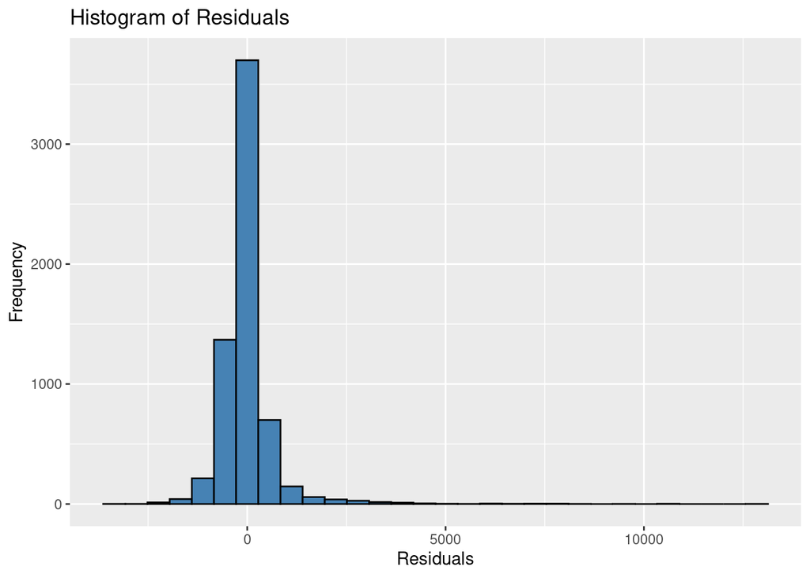

```r
library(ggplot2)
ggplot(data = train, aes(x = model1$residuals)) +
    geom_histogram(fill = 'steelblue', color = 'black') +
    labs(title = 'Histogram of Residuals', x = 'Residuals', y = 'Frequency')
```

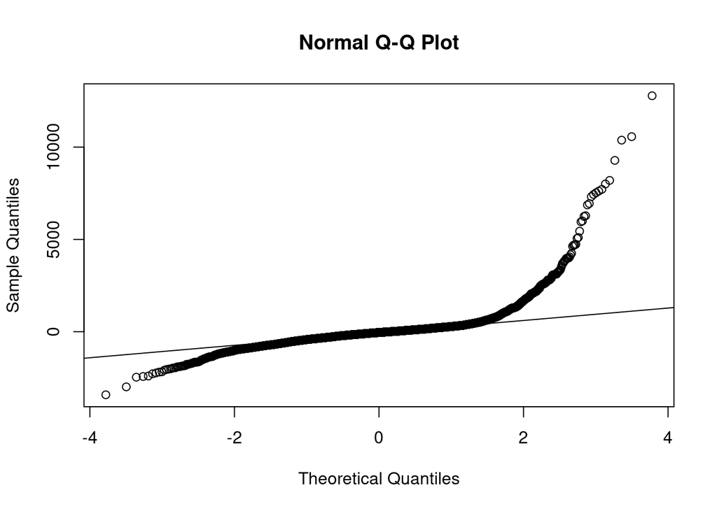

```r
qqnorm(model1$residuals)

qqline(model1$residuals)
```

Clarament mirant els dos plots es veu que no es comporta com una normal, ja que tenim valors outliners molt forts sobretot els que son més grans. Això pot ser degut a que el habitage es més car que el que les seves característiques indicaria degut a factors com la zona o altres variables les quals no estan contemplades al model, ja que com vam veure teniem pisos que eren molt més cars que els del seu voltant ja que la mitjana era molt major a la mediana en alguns barris. També veiem que tenim una cua per la esquerra per sota de la linea, encara que menys pronunciada, això pot ser per lloguer vells que mantenen rentes antigues que estan per sota del mercat actual per tant estan per sota de l’esperat

### 1.7 Predicció del model

Segons el model final, calculeu les prediccions del preu de lloguer d’un pis a Barcelona, utilitzant la base de dades de test. Representeu els valors predits front els valors observats. Avalueu la precisió del model mitjançant l’arrel quadrada de l’error quadràtic mitjà (RMSE). Interpreteu.

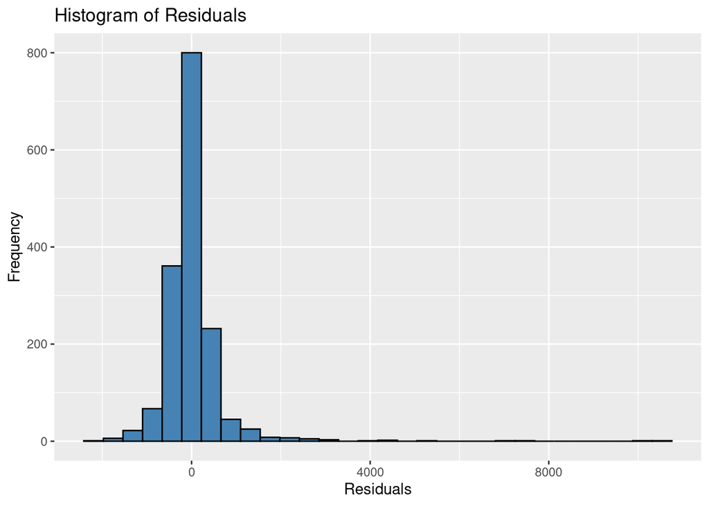

```r
predictions <- predict(model1, newdata = test)
residuals <-  test$price - predictions
ggplot(data = test, aes(x = residuals)) +
    geom_histogram(fill = 'steelblue', color = 'black') +
    labs(title = 'Histogram of Residuals', x = 'Residuals', y = 'Frequency')
```

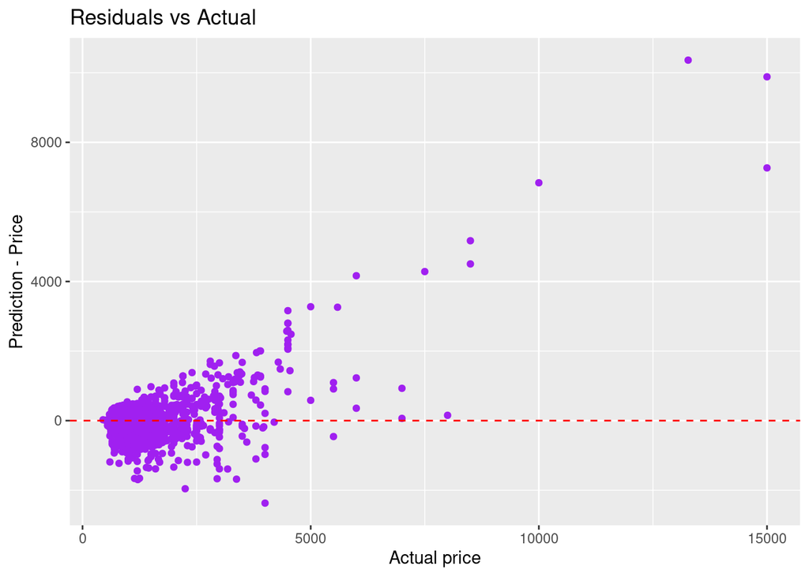

```r
library(ggplot2)

ggplot(data.frame(Actual = test$price, Residuals = residuals), aes(x = Actual, y = Residuals)) +
  geom_point(color = "purple") +
  geom_hline(yintercept = 0, linetype = "dashed", color = "red") +
  labs(title = "Residuals vs Actual", x = "Actual price", y = "Prediction - Price")
```

```r
rmse <- sqrt(mean(residuals^2))
print(paste("RMSE:", round(rmse, 4)))
```

```
## [1] "RMSE: 703.064"
```

Veiem un resultat similar on els preus alts li costa molt predir-los, i per una diferencia molt significativa tenit un RSME de 700 indicant que que aquest valors que se equivoca ho fa molt, per exemple podem veure que el valor mes gran que esta al voltant de 15000 € se equivoca al predir-lo per més de 8000 € amb diferencies tant grans en la part alta dels preus fan que el model no pugui predir aquest ouliners i tingui estadístiques molt dolentes encara que veiem que la majoria de punts si que estan millor predits.

## 2 Regressió logística

### 2.1 Preparació de les dades

Es vol estudiar quins són els factors que més influeixen en el preu per metre quadrat de lloguer dels habitatges a la ciutat de Barcelona.

Primer es crearà una nova variable anomenada **square_meters_price**. Aquesta nova variable està relacionada amb els valors de la variable price i square_meters. Posteriorment es convertirà a variable dicotòmica **square_meters_price_re**. Es recodificarà de la manera següent: “preu per metre quadrat inferior a 20 euros” pren el valor 0 i “preu superior o igual a 20” el valor 1. Per a evitar problemes de multicolinealitat, una vegada creada aquesta variable dicotòmica, no es tindran en compte els factors **price** i **squared_meters**, per a la creació dels models. De la mateixa forma, tampoc es tindrà en compte **square_meters_price**. Per al model de regressió logística, es prendrà com a variable dependent **square_meters_price_re**.

De manera anàloga als models lineals, separarem el conjunt de dades en dues parts: el conjunt d’entrenament (training) i el conjunt de prova (testing). Ajustarem el model de regressió logística amb el conjunt d’entrenament, i avaluarem la precisió amb el conjunt de prova. Es pot fixar la grandària de la mostra d’entrenament a un 80% de l’original.

```r
data_rl <- data
data_rl$square_meters_price <- data_rl$price/data_rl$square_meter
data_rl <- data_rl%>% mutate(square_meters_price_re = ifelse(square_meters_price >= 20, 1, 0))
smp_size <- floor(0.80 * nrow(data_rl))

## set the seed to make your partition reproducible
set.seed(123)
train_ind <- sample(seq_len(nrow(data_rl)), size = smp_size)

train_rl <- data_rl[train_ind, ]
test_rl <- data_rl[-train_ind, ]
```

### 2.2 Estimació del model de regressió logística amb el conjunt d’entrenament

Prenent com a base, training, estimeu el model de regressió logística sent la variable dependent **squared_meters_price_re** i prenent la resta de variables de la base de dades training, com a factors explicatius, tenint en compte les consideracions esmentades, per a evitar problemes de multicolinealitat.

Respecte a les variables **neighborhood** i **real_state**, es prendran com a valors de referència Ciutat Vella i flat. A la vista dels resultats, explica si eliminaries o no algun dels factors del model.

```r
modellr1 <- glm(square_meters_price_re ~ rooms + bathroom + factor(lift) + factor(terrace) + relevel(factor(real_state),ref = "flat") + relevel(factor(neighborhood),ref = "Sarria-Sant Gervasi"), data = train_rl ,family=binomial(link=logit))
summary(modellr1)
```

```
##
## Call:
## glm(formula = square_meters_price_re ~ rooms + bathroom + factor(lift) +
##     factor(terrace) + relevel(factor(real_state), ref = "flat") +
##     relevel(factor(neighborhood), ref = "Sarria-Sant Gervasi"),
##     family = binomial(link = logit), data = train_rl)
##
## Coefficients:
##                                                                           Estimate
## (Intercept)                                                               -0.64391
## rooms                                                                     -0.69831
## bathroom                                                                   0.58029
## factor(lift)TRUE                                                          -0.39012
## factor(terrace)TRUE                                                        0.23608
## relevel(factor(real_state), ref = "flat")apartment                         2.10704
## relevel(factor(real_state), ref = "flat")attic                             1.14616
## relevel(factor(real_state), ref = "flat")study                             0.87104
## relevel(factor(neighborhood), ref = "Sarria-Sant Gervasi")Ciutat Vella    -0.04508
## relevel(factor(neighborhood), ref = "Sarria-Sant Gervasi")Eixample         0.21057
## relevel(factor(neighborhood), ref = "Sarria-Sant Gervasi")Gracia          -0.36749
## relevel(factor(neighborhood), ref = "Sarria-Sant Gervasi")Horta- Guinardo -1.71716
## relevel(factor(neighborhood), ref = "Sarria-Sant Gervasi")Les Corts       -0.68311
## relevel(factor(neighborhood), ref = "Sarria-Sant Gervasi")Nou Barris      -3.02893
## relevel(factor(neighborhood), ref = "Sarria-Sant Gervasi")Sant Andreu     -2.08061
## relevel(factor(neighborhood), ref = "Sarria-Sant Gervasi")Sant Mart<ed>    0.22850
## relevel(factor(neighborhood), ref = "Sarria-Sant Gervasi")Sants-Montjuic  -0.50829
##                                                                           Std. Error
## (Intercept)                                                                  0.13683
## rooms                                                                        0.04300
## bathroom                                                                     0.06012
## factor(lift)TRUE                                                             0.08009
## factor(terrace)TRUE                                                          0.08974
## relevel(factor(real_state), ref = "flat")apartment                           0.09206
## relevel(factor(real_state), ref = "flat")attic                               0.15058
## relevel(factor(real_state), ref = "flat")study                               0.23406
## relevel(factor(neighborhood), ref = "Sarria-Sant Gervasi")Ciutat Vella       0.11704
## relevel(factor(neighborhood), ref = "Sarria-Sant Gervasi")Eixample           0.10170
## relevel(factor(neighborhood), ref = "Sarria-Sant Gervasi")Gracia             0.15405
## relevel(factor(neighborhood), ref = "Sarria-Sant Gervasi")Horta- Guinardo    0.31487
## relevel(factor(neighborhood), ref = "Sarria-Sant Gervasi")Les Corts          0.18511
```

[output cut: 53 more lines]

```
## relevel(factor(neighborhood), ref = "Sarria-Sant Gervasi")Les Corts       ***
## relevel(factor(neighborhood), ref = "Sarria-Sant Gervasi")Nou Barris      **
## relevel(factor(neighborhood), ref = "Sarria-Sant Gervasi")Sant Andreu     ***
## relevel(factor(neighborhood), ref = "Sarria-Sant Gervasi")Sant Mart<ed>
## relevel(factor(neighborhood), ref = "Sarria-Sant Gervasi")Sants-Montjuic  **
## ---
## Signif. codes:  0 '***' 0.001 '**' 0.01 '*' 0.05 '.' 0.1 ' ' 1
##
## (Dispersion parameter for binomial family taken to be 1)
##
##     Null deviance: 6842.6  on 6358  degrees of freedom
## Residual deviance: 5388.6  on 6342  degrees of freedom
## AIC: 5422.6
##
## Number of Fisher Scoring iterations: 7
```

```r
train_rl$neighborhood[train_rl$neighborhood %in% c("Sarria-Sant Gervasi", "Ciutat Vella")] <- "Sarria-Sant Gervasi"
test_rl$neighborhood[test_rl$neighborhood %in% c("Sarria-Sant Gervasi", "Ciutat Vella")] <- "Sarria-Sant Gervasi"
modellr1 <- glm(square_meters_price_re ~ rooms + bathroom + factor(lift) + factor(terrace) + relevel(factor(real_state),ref = "flat") + relevel(factor(neighborhood),ref = "Sarria-Sant Gervasi"), data = train_rl ,family=binomial(link=logit))
summary(modellr1)
```

```
##
## Call:
## glm(formula = square_meters_price_re ~ rooms + bathroom + factor(lift) +
##     factor(terrace) + relevel(factor(real_state), ref = "flat") +
##     relevel(factor(neighborhood), ref = "Sarria-Sant Gervasi"),
##     family = binomial(link = logit), data = train_rl)
##
## Coefficients:
##                                                                           Estimate
## (Intercept)                                                               -0.67811
## rooms                                                                     -0.69658
## bathroom                                                                   0.58179
## factor(lift)TRUE                                                          -0.38366
## factor(terrace)TRUE                                                        0.23644
## relevel(factor(real_state), ref = "flat")apartment                         2.10636
## relevel(factor(real_state), ref = "flat")attic                             1.14774
## relevel(factor(real_state), ref = "flat")study                             0.87201
## relevel(factor(neighborhood), ref = "Sarria-Sant Gervasi")Eixample         0.23355
## relevel(factor(neighborhood), ref = "Sarria-Sant Gervasi")Gracia          -0.34198
## relevel(factor(neighborhood), ref = "Sarria-Sant Gervasi")Horta- Guinardo -1.69080
## relevel(factor(neighborhood), ref = "Sarria-Sant Gervasi")Les Corts       -0.66121
## relevel(factor(neighborhood), ref = "Sarria-Sant Gervasi")Nou Barris      -3.00357
## relevel(factor(neighborhood), ref = "Sarria-Sant Gervasi")Sant Andreu     -2.05389
## relevel(factor(neighborhood), ref = "Sarria-Sant Gervasi")Sant Mart<ed>    0.25201
## relevel(factor(neighborhood), ref = "Sarria-Sant Gervasi")Sants-Montjuic  -0.48242
##                                                                           Std. Error
## (Intercept)                                                                  0.10424
## rooms                                                                        0.04276
## bathroom                                                                     0.06000
## factor(lift)TRUE                                                             0.07831
## factor(terrace)TRUE                                                          0.08975
## relevel(factor(real_state), ref = "flat")apartment                           0.09204
## relevel(factor(real_state), ref = "flat")attic                               0.15053
## relevel(factor(real_state), ref = "flat")study                               0.23403
## relevel(factor(neighborhood), ref = "Sarria-Sant Gervasi")Eixample           0.08254
## relevel(factor(neighborhood), ref = "Sarria-Sant Gervasi")Gracia             0.13913
## relevel(factor(neighborhood), ref = "Sarria-Sant Gervasi")Horta- Guinardo    0.30729
## relevel(factor(neighborhood), ref = "Sarria-Sant Gervasi")Les Corts          0.17621
## relevel(factor(neighborhood), ref = "Sarria-Sant Gervasi")Nou Barris         1.01657
## relevel(factor(neighborhood), ref = "Sarria-Sant Gervasi")Sant Andreu        0.48639
```

[output cut: 48 more lines]

```
## relevel(factor(neighborhood), ref = "Sarria-Sant Gervasi")Les Corts       ***
## relevel(factor(neighborhood), ref = "Sarria-Sant Gervasi")Nou Barris      **
## relevel(factor(neighborhood), ref = "Sarria-Sant Gervasi")Sant Andreu     ***
## relevel(factor(neighborhood), ref = "Sarria-Sant Gervasi")Sant Mart<ed>   .
## relevel(factor(neighborhood), ref = "Sarria-Sant Gervasi")Sants-Montjuic  **
## ---
## Signif. codes:  0 '***' 0.001 '**' 0.01 '*' 0.05 '.' 0.1 ' ' 1
##
## (Dispersion parameter for binomial family taken to be 1)
##
##     Null deviance: 6842.6  on 6358  degrees of freedom
## Residual deviance: 5388.8  on 6343  degrees of freedom
## AIC: 5420.8
##
## Number of Fisher Scoring iterations: 7
```

El AIC ha baixat per tant segons aquest indicador hem millorat el model

### 2.3 Càlcul de les OR (Odss-Ràtio)

Calculeu les OR corresponents i interpreteu les que considereu més rellevants. Resumir quines de les variables poden considerar-se factors de risc o protecció.

```r
kable(exp(coef(modellr1)))
```

|  | x |
| --- | --- |
| (Intercept) | 0.5075759 |
| rooms | 0.4982850 |
| bathroom | 1.7892439 |
| factor(lift)TRUE | 0.6813606 |
| factor(terrace)TRUE | 1.2667337 |
| relevel(factor(real_state), ref = “flat”)apartment | 8.2182949 |
| relevel(factor(real_state), ref = “flat”)attic | 3.1510698 |
| relevel(factor(real_state), ref = “flat”)study | 2.3917079 |
| relevel(factor(neighborhood), ref = “Sarria-Sant Gervasi”)Eixample | 1.2630745 |
| relevel(factor(neighborhood), ref = “Sarria-Sant Gervasi”)Gracia | 0.7103647 |
| relevel(factor(neighborhood), ref = “Sarria-Sant Gervasi”)Horta- Guinardo | 0.1843721 |
| relevel(factor(neighborhood), ref = “Sarria-Sant Gervasi”)Les Corts | 0.5162261 |
| relevel(factor(neighborhood), ref = “Sarria-Sant Gervasi”)Nou Barris | 0.0496098 |
| relevel(factor(neighborhood), ref = “Sarria-Sant Gervasi”)Sant Andreu | 0.1282346 |
| relevel(factor(neighborhood), ref = “Sarria-Sant Gervasi”)Sant Mart | 1.2866100 |
| relevel(factor(neighborhood), ref = “Sarria-Sant Gervasi”)Sants-Montjuic | 0.6172871 |

### 2.4 Matriu de confusió

A continuació analitzeu la matriu de confusió i les mesures de sensibilitat i especificitat. S’assumirà que la predicció del model és 1, si la probabilitat del model de regressió logística és superior o igual a 0.5 i 0 en cas contrari. Calculeu la predicció del model contra el conjunt de prova (testing).

```r
#install.packages("caret")
library(caret)
pred_probs <- predict(modellr1, newdata = test_rl, type = "response")
pred <- ifelse(pred_probs >= 0.5, 1, 0)
actual <- as.numeric(test_rl$square_meters_price_re)
pred_factor <-factor(pred, levels = c(0, 1))
actual_factor <- factor(actual, levels = c(0, 1))

confusionMatrix(pred_factor, actual_factor)
```

```
## Confusion Matrix and Statistics
##
##           Reference
## Prediction    0    1
##          0 1159  227
##          1   61  143
##
##                Accuracy : 0.8189
##                  95% CI : (0.799, 0.8375)
##     No Information Rate : 0.7673
##     P-Value [Acc > NIR] : 3.335e-07
##
##                   Kappa : 0.3988
##
##  Mcnemar's Test P-Value : < 2.2e-16
##
##             Sensitivity : 0.9500
##             Specificity : 0.3865
##          Pos Pred Value : 0.8362
##          Neg Pred Value : 0.7010
##              Prevalence : 0.7673
##          Detection Rate : 0.7289
##    Detection Prevalence : 0.8717
##       Balanced Accuracy : 0.6682
##
##        'Positive' Class : 0
##
```

Tenim una acurracy bastant bona al voltant del 80% però la nostra especificitat es bastant dolenta, això pot ser pel poc balanç a les nostres dades on tenin 1456 positius i 4903 negatius a train. Aquest desvalanç a les dades de train pot fer que acabi predient millor la classe més gran, en aquest cas la negativa, per tant no es d’estranyar aquest comportament que veiem a la matriu de confusió.

### 2.5 Predicció

Identifiqueu els habitatges més cars, és a dir aquelles la probabilitat de les quals d’estar classificades amb el valor “1”, sigui superior al 50%, segons el model de prediccions contra el conjunt de prova (testing). Posteriorment mostreu en una taula el barri i tipus d’habitatge, al qual pertanyen.

```r
library(dplyr)


test_rl2 <- data_rl[-train_ind, ]
df2 <-  test_rl2 %>%
  mutate(pred_prob = predict(modellr1, newdata = test_rl, type = "response")) %>%
  filter(pred_prob > 0.5) %>% group_by(neighborhood, real_state) %>%
  dplyr::summarise(total_count=n(),.groups = 'drop') %>%
  as.data.frame()
kable(df2)
```

| neighborhood | real_state | total_count |
| --- | --- | --- |
| Ciutat Vella | apartment | 49 |
| Ciutat Vella | attic | 4 |
| Ciutat Vella | flat | 2 |
| Ciutat Vella | study | 6 |
| Eixample | apartment | 76 |
| Eixample | attic | 8 |
| Eixample | flat | 2 |
| Eixample | study | 1 |
| Gracia | apartment | 9 |
| Gracia | flat | 1 |
| Gracia | study | 2 |
| Les Corts | apartment | 5 |
| Sant Mart | apartment | 5 |
| Sant Mart | attic | 3 |
| Sant Mart | study | 2 |
| Sants-Montjuic | apartment | 8 |
| Sants-Montjuic | attic | 1 |
| Sarria-Sant Gervasi | apartment | 15 |
| Sarria-Sant Gervasi | attic | 3 |
| Sarria-Sant Gervasi | study | 2 |

Veiem que tenim Barris on el preu per metre quadrat es alt en tots els tipus d’habitatge i el nombre es molt alt per exemple ciutat vella o eixaple el que fa pensar que son barris on el preu per metre quadrat es alt en general en canvi tenim barris on es estrany trobar-ho. Per tant sembla que el model ha pogut inferir quins barris son els que tenen un preu per metre quadrat elevat

### 2.6 Bondat de l’ajust i corba ROC

Avalueu l’eficàcia del model segons el test Chi-quadrat. En aquest cas el valor de l’estadístic Chi-quadrat observat és igual a la diferència de devianzas (nul·la-residual). Calculeu la probabilitat associada a l’estadístic del contrast utilitzant la funció **pchisq**.

Una vegada avaluada l’eficàcia, dibuixeu la corba ROC i calcular l’àrea sota la corba. Discutiu el resultat

```r
print(sum(residuals(modellr1,type="pearson")^2))
```

```
## [1] 6376.491
```

```r
print(1-pchisq(sum(residuals(modellr1,type="pearson")^2),1))
```

```
## [1] 0
```

```r
library(pROC)
prob <- predict(modellr1, newdata = test_rl, type = "response")
r <- roc(test_rl$square_meters_price_re,prob, data=test_rl)
```

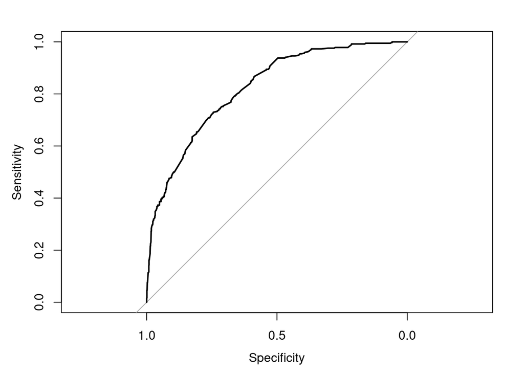

```r
## Setting levels: control = 0, case = 1
## Setting direction: controls < cases
plot (r)
```

```r
print(auc(r))
```

```
## Area under the curve: 0.8225
```

Veiem que Chi-quadrat té la mateixa distribució asimptòtica que la de la diferència de les devianze del model, per tant el model es bo.

Mirant l’àrea sota la corba veiem que es de 0.82 per tant el model discrimina de forma excel·lent. Clarament això es veu on la nostra corba esta molt per sobre que la recta entre 0 i 1.

### 2.7 Model de regressió logística multinomial

Es crearà un model de regressió logística multinomial, per a classificar el tipus d’habitatges. Per a això es prendrà com a variable dependent real_state i les variables explicatives price, rooms, bathroom i square_meters. Analitzeu la precisió del model, comparant la predicció del model contra el conjunt de prova (testing). Interpreteu.

```r
library(nnet)
data_mn <- data
smp_size <- floor(0.80 * nrow(data_mn))

## set the seed to make your partition reproducible
set.seed(123)
train_ind <- sample(seq_len(nrow(data_mn)), size = smp_size)

train_mn <- data_mn[train_ind, ]
test_mn <- data_mn[-train_ind, ]
modellmn <- multinom(real_state ~ price + rooms + bathroom + square_meters, data=train_mn)
summary(modellmn)
```

```
## Call:
## multinom(formula = real_state ~ price + rooms + bathroom + square_meters,
##     data = train_mn)
##
## Coefficients:
##       (Intercept)         price      rooms   bathroom square_meters
## attic   -2.141013 -0.0005071447  0.1205752 0.12339735   0.017861889
## flat     1.001871 -0.0014299798  0.4813460 0.06469345   0.023809687
## study    2.227822 -0.0027187925 -2.0622666 0.82911054  -0.005460894
##
## Std. Errors:
##       (Intercept)        price      rooms   bathroom square_meters
## attic 0.059333359 7.315401e-05 0.08499975 0.11501763   0.002598748
## flat  0.082285055 6.390186e-05 0.05495460 0.08918366   0.002072405
## study 0.005430746 5.255585e-04 0.01571506 0.01087154   0.009443384
##
## Residual Deviance: 6353.695
## AIC: 6383.695
```

```r
pred <- predict(modellmn, newdata = test_mn)
actual_class <- factor(test_mn$real_state)
pred_class <-factor(pred, levels = levels(actual_class))

confusionMatrix(pred_class, actual_class)
```

```
## Confusion Matrix and Statistics
##
##            Reference
## Prediction  apartment attic flat study
##   apartment        42     3   13     0
##   attic             1     0    1     0
##   flat            151    62 1282    24
##   study             1     0    3     7
##
## Overall Statistics
##
##                Accuracy : 0.8371
##                  95% CI : (0.818, 0.8549)
##     No Information Rate : 0.817
##     P-Value [Acc > NIR] : 0.01941
##
##                   Kappa : 0.2418
##
##  Mcnemar's Test P-Value : NA
##
## Statistics by Class:
##
##                      Class: apartment Class: attic Class: flat Class: study
## Sensitivity                   0.21538     0.000000      0.9869     0.225806
## Specificity                   0.98853     0.998689      0.1856     0.997434
## Pos Pred Value                0.72414     0.000000      0.8440     0.636364
## Neg Pred Value                0.90013     0.959068      0.7606     0.984801
## Prevalence                    0.12264     0.040881      0.8170     0.019497
## Detection Rate                0.02642     0.000000      0.8063     0.004403
## Detection Prevalence          0.03648     0.001258      0.9553     0.006918
## Balanced Accuracy             0.60196     0.499344      0.5862     0.611620
```

El model te problemes per diferencia certes classes degut al imbalanç de les dades ja que la majoria son pisos es molt complicat que pugui entendre les altres classes, ja que totes les demès classes sumades no representen ni un terç de les que tenim en pis, en concret tenim 5218 pisos i 1141 dels demès. Aquest biaix cap els pisos fa que el nostre model predictiu no pugui generalitzar adequadament, ja que un model que només digues pis, tindria una accuracy del 82%. Tenint en compte això no es estrany veure perquè li costa generalitzar.

## 3 Resum executiu. Conclusions de l’anàlisi

Resumiu les conclusions de l’estudi en una taula, indicant les respostes a les preguntes de recerca plantejades. Cada fila de la taula, es correspondrà a un apartat. S’haurà d’indicar de manera concisa, la pregunta, els resultats estadístics i breu conclusió.

[output not shown]